# Data Visualization Assignment 2

Denis Tan, dwt2118, Columbia University

February 25, 2015

# 1 Assignment 2

## 1.1 Assignment Summary

We are asked to recreate the following plot found at: http://www.informationisbeautiful.net/visualizations/the-microbescope/ using R.

## 1.2 Preset

I first load the requisite R packages: ggplot2 and scales

```r
# Load Libraries
library(ggplot2)
library(scales)
```

## 1.3 Read Data

I then read the data from my local github folder using the read.csv function.

```r
# Change directory
setwd("~/data-viz/ebola")

# Read Data
germs <- read.csv(file="Microbe-scope-bugs.csv", header=TRUE)
```

## 1.4 Pre-Processing

Following which, I adopt the pre-processing code provided by Prof Cohen to clean up the messy data.

```r
# assign descriptive column names where absent
names(germs)[1]<-"germ"

# how could you do this more carefully???
# names(germs)[10]<-"yearly.fatalities.rounded"
# names(germs)[11]<-"yearly.fatalities.raw"

# keep only data columns, exclude notes/links
notes <- germs[1, ] # save the notes?
germs <- germs[-1, ] # remove **row** of notes
# germs <- germs[, c(2, 4:7, 9:11)] # keep data **columns** only
# how could you do this more carefully??? e.g. remove the columns you intend to remove.

# how about something like this?
notes <- grep(pattern="note", x=names(germs), ignore.case=TRUE)
names(germs)[notes] # double check we got the right columns
```

```
## [1] "note"   "note.1" "note.2"
```

```r
germs <- subset(germs, select = -notes) # apply filter.

# any more columns we want to omit?

# remove percent signs
dropPct<-function(df, var){
        dropPct<-strsplit(as.character(df[[var]]), split="%")
        df[[var]]<-as.numeric(dropPct)
        return(df[[var]])
}

# remove % signs, leaving a numeric value.
germs[["case.fatality.rate"]]<-dropPct(germs, "case.fatality.rate")

# Convert basic reproductive rate from factor to numeric
germs$average.basic.reproductive.rate <- as.numeric(as.character(germs$average.basic.reproductive.rate))
```

## 1.5 Further Processing

I also apply some further processing steps. These include dropping the Malaria (P. falciparum) data point, removing rows with missing data values, subsetting the data frame such that only variables required for plotting are kept, reaffirming that there are no missing data, and renaming variables that have the exact same value for the X and Y axis. This is necessary to prevent the data labelling process from create overlapped labels. Malaria (P. falciparum) is dropped as it distorts the visualization - it has more than 4 times the contagiousness of any other microbes.

```r
# Drop Malaria (P. falciparum) just as Website did
germs <- subset(germs, germ != "Malaria (P. falciparum)")

# Drop missing data for transmission mode
germs <- subset(germs, primary.mode.of.transmission != "")

# Keep only required columns
germs <- germs[,c(1:4)]

# Make sure no missing data
germs <- germs[complete.cases(germs),]

# Deal with duplicate data points
germs$germ <- as.character(germs$germ)
germs$germ[1] <- "Bird Flu (H5N1) & Bubo. Pla. (untrd)"
germs$germ[2] <- "Bird Flu (H5N1) & Bubo. Pla. (untrd)"
germs$germ[25] <- "Rhinovirus & Rubella"
germs$germ[27] <- "Rhinovirus & Rubella"


# Since using log plot, set 0 values to small nominal value of 0.001
germs$case.fatality.rate[germs$case.fatality.rate == 0] <- 0.001
```

## 1.6 Base Plot

I then proceed to use ggplot to visualize the data. The horizontal axis depicts the average basic reproductive rate of the microbe, the vertical acis depicts the case fatality rate of the microbe, and the color depicts the primary mode of transmission. 3 dimensions of data are hence shown.

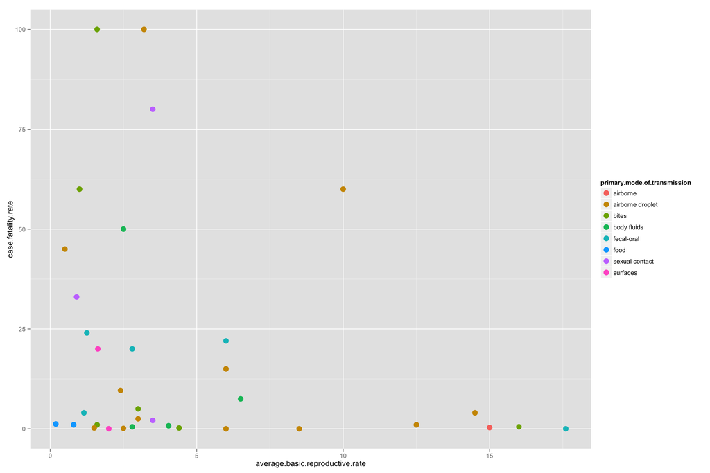

```r
# Plot
p <- ggplot(germs, aes(x=average.basic.reproductive.rate, y=case.fatality.rate, group =primary.mode.of.transmission, colour=primary.mode.of.transmission)) +
        geom_point(size=4)
print(p)
```

## 1.7 Add Title, Amend Axis Names and Legend Name

Following which, I try to beautify the plot by correcting the plot text. I leave the vertical axis unchanged at this point.

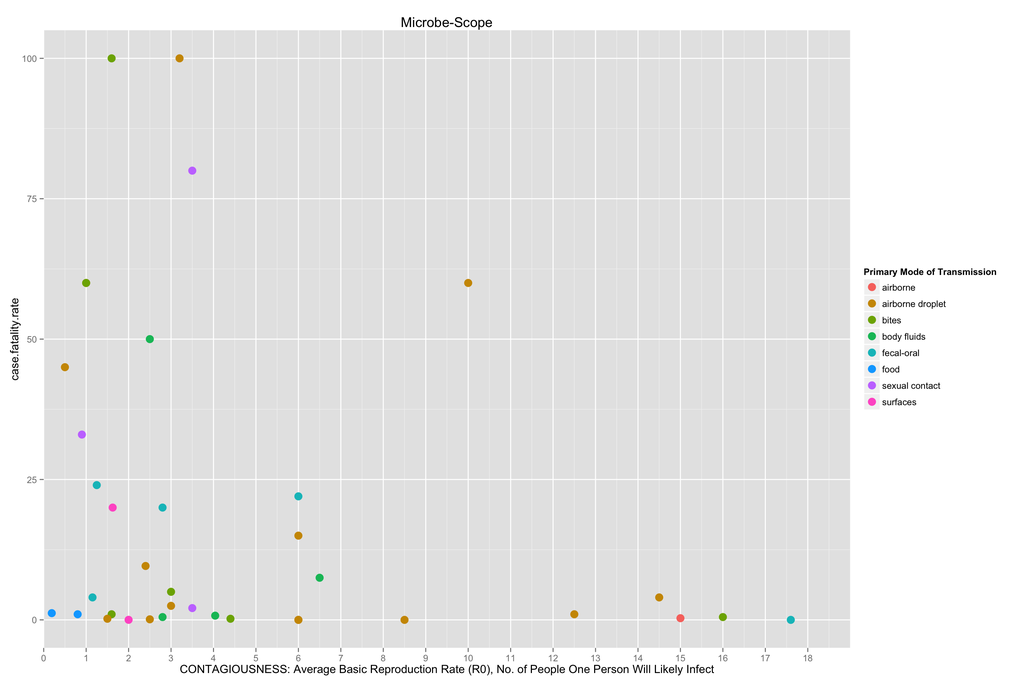

```r
p <- p + scale_color_discrete(name="Primary Mode of Transmission") +
        ggtitle("Microbe-Scope") +
        scale_x_continuous("CONTAGIOUSNESS: Average Basic Reproduction Rate (R0), No. of People One Person Will Likely Infect", limits=c(0, 19), breaks=c(0,1,2,3,4,5,6,7,8,9,10,11,12,13,14,15,16,17,18), expand = c(0,0))
print(p)
```

## 1.8 Modify Vertical Axis

While I correct the vertical axis text, I noticed that many data points are clustered at or near the 0 case fatality rate region. This will create problems when applying data labels. Hence, I decided to use a log scale on the vertical axis.

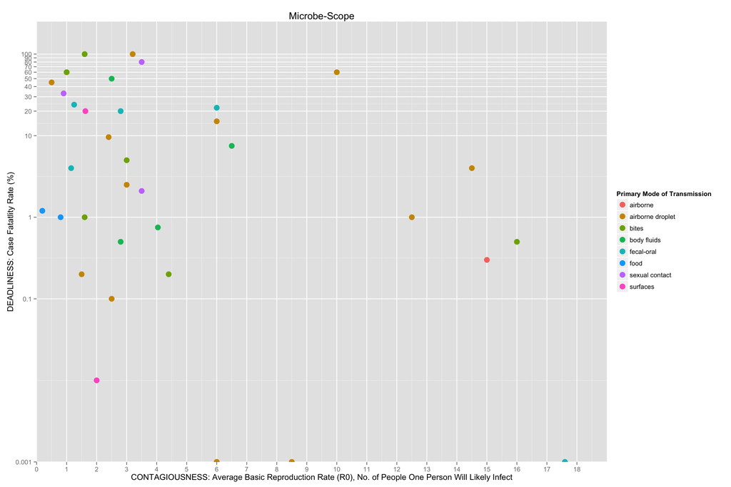

```r
p <- p + scale_y_log10("DEADLINESS: Case Fatatlity Rate (%)", limits = c(0.001,250), breaks =c(0.001, 0.1, 1,10, 20,30,40,50,60,70,80,90,100), labels = c(0.001, 0.1, 1,10, 20,30,40,50,60,70,80,90,100), expand = c(0,0.001))
print(p)
```

## 1.9 Further simplication of chart to reduce non-data ink

Recalling the words of Tufte, I seek to simplify the chart to maximize data-ink. Here, I use theme_bw to use the most basic plot background possible.

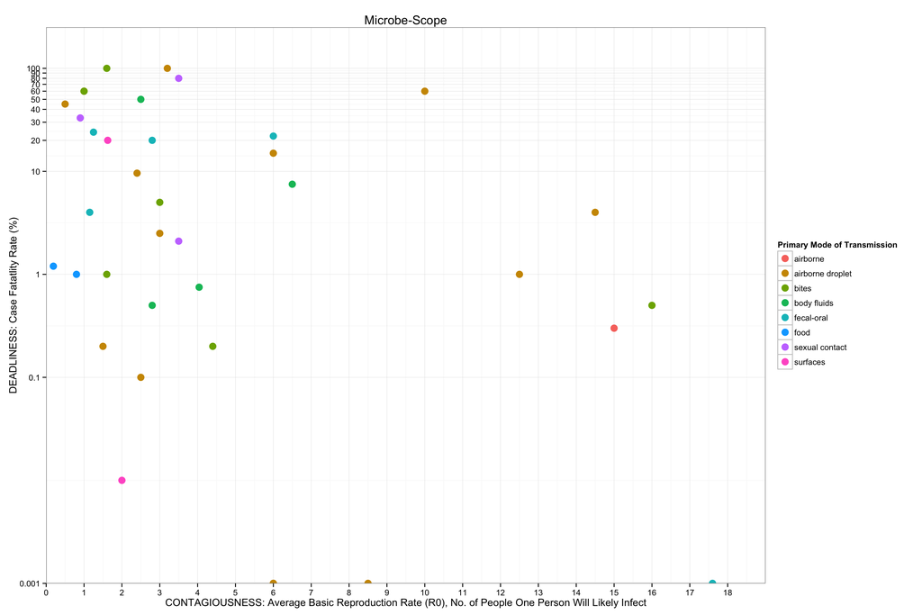

```r
p <- p + theme_bw()
print(p)
```

## 1.10 Data Labelling

Then, I label the data points. I apply a 10 degree tilt and used trial and error to decide the font size, horizontal adjustment, and vertical adjustment to reduce the overlapping label problem.

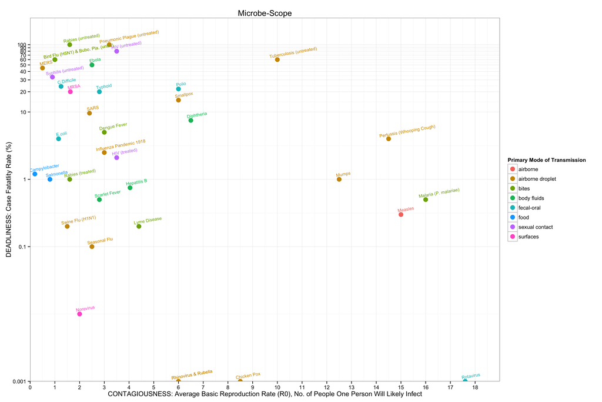

```r
p <- p+ geom_text(aes(label = germ, hjust = 0.15, vjust=-0.9, angle = 10), size=2.8)
print(p)
```

## 1.11 Annotation

Finally, I apply annotations as reflected on the original Microbe-Scope graphic to better explain the data to the lay person.

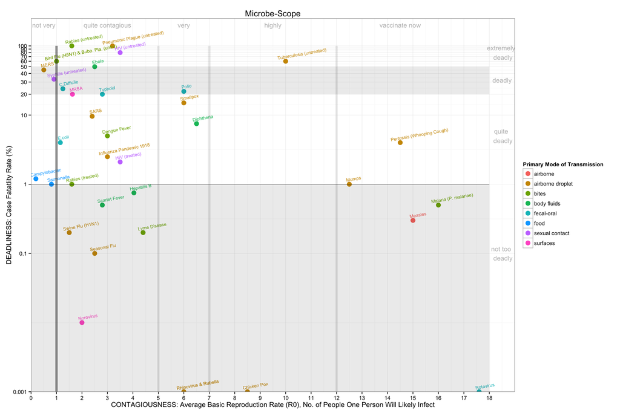

```r
p <- p+ annotate("rect", xmin = 0, xmax = 18, ymin = 20, ymax = 50,
                 alpha = .1) +
        annotate("rect", xmin = 0, xmax = 18, ymin = 0, ymax = 1,
                 alpha = .1) +
        annotate("rect", xmin = 4.95, xmax = 5.05, ymin = 0, ymax = 100,
                 alpha = .1) +
        annotate("rect", xmin = 6.95, xmax = 7.05, ymin = 0, ymax = 100,
                 alpha = .1) +
        annotate("rect", xmin = 11.95, xmax = 12.05, ymin = 0, ymax = 100,
                 alpha = .1) +
        annotate("rect", xmin = 0, xmax = 18, ymin = 0.99, ymax = 1.01,
                 alpha = .5) +
        annotate("rect", xmin = 0.95, xmax = 1.05, ymin = 0, ymax = 100,
                 alpha = .5) +
        annotate("text", x = 0.5, y = 200, label = c("not very"), size=4, colour = "grey") +
        annotate("text", x = 3, y = 200, label = c("quite contagious"), size=4, colour = "grey") +
        annotate("text", x = 6, y = 200, label = c("very"), size=4, colour = "grey") +
        annotate("text", x = 9.5, y = 200, label = c("highly"), size=4, colour = "grey") +
        annotate("text", x = 14.5, y = 200, label = c("vaccinate now"), size=4, colour = "grey") +
        annotate("text", x = 18.5, y = 0.1, label = c("not too \n deadly"), size=4, colour = "grey") +
        annotate("text", x = 18.5, y = 5, label = c("quite \n deadly"), size=4, colour = "grey") +
        annotate("text", x = 18.5, y = 32, label = c("deadly"), size=4, colour = "grey") +
        annotate("text", x = 18.5, y = 80, label = c("extremely \n deadly"), size=4, colour = "grey")
print(p)
```

## 1.12 Conclusion

The 2nd assignment has been completed in R using the ggplot and scales packages.